# **Bartlett Environmental Course Curriculum**

[TOC]

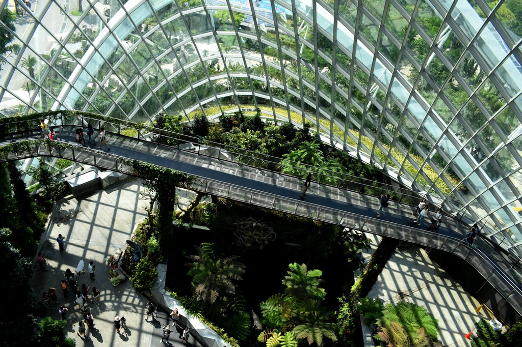

## Introduction

This brief introduction to this Environment Science course does several things: *describing* the goals for the course; *discussing* the design principles employed; *outlining* the Essential Questions and Big Ideas/Enduring Understandings; and *outlining* the Massachusetts learning standards addressed.

### Goal of the Course

The goal of this Environment Science course is threefold:

1. **Enhance** the science experience of incoming freshmen.
2. Allow students to **explore** the key concepts of the course through student-centered pedagogical strategies, such as: [project-based learning](https://www.edutopia.org/project-based-learning), [design thinking](https://www.ideo.com/post/design-thinking-for-educators), and [inquiry-based learning](https://www.edutopia.org/blog/what-heck-inquiry-based-learning-heather-wolpert-gawron).
3. Provide students with a **rich experience** of environmental science, sustainability, and human impact on the environment.

### Essential Questions and Big Ideas/Enduring Understandings

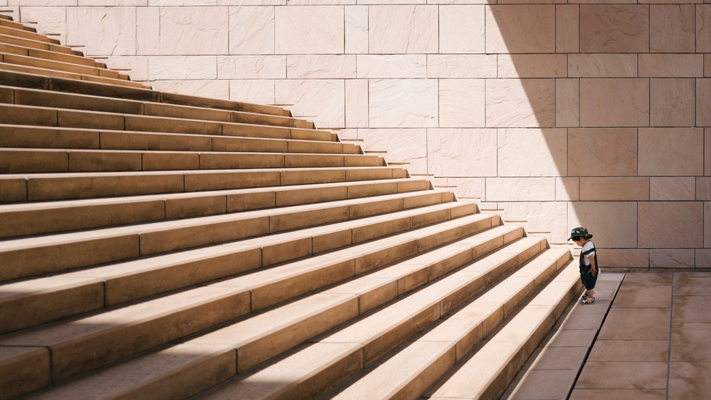

1. Living and non-things things are connected via [**complex, adaptive systems**](https://en.wikipedia.org/wiki/Complex_adaptive_system). When you touch one thing, you touch everything.
2. Living systems tend toward [**homeostasis**](https://en.wikipedia.org/wiki/Homeostasis), however humans have an outsized impact on the environment which threatens this homeostasis.
3. People can learn to come together to design solutions that can positively influence the [**sustainability**](https://www.epa.gov/sustainability/learn-about-sustainability) of our world.

1. How do living and non-living systems work and work together and respond to one another?
2. What is the value of diversity in terms of living and non-living systems, and how can this diversity be expanded?
3. In what ways have we had negative impacts on our world and how can we repair the damage we have caused?

### Learning Standards Addressed

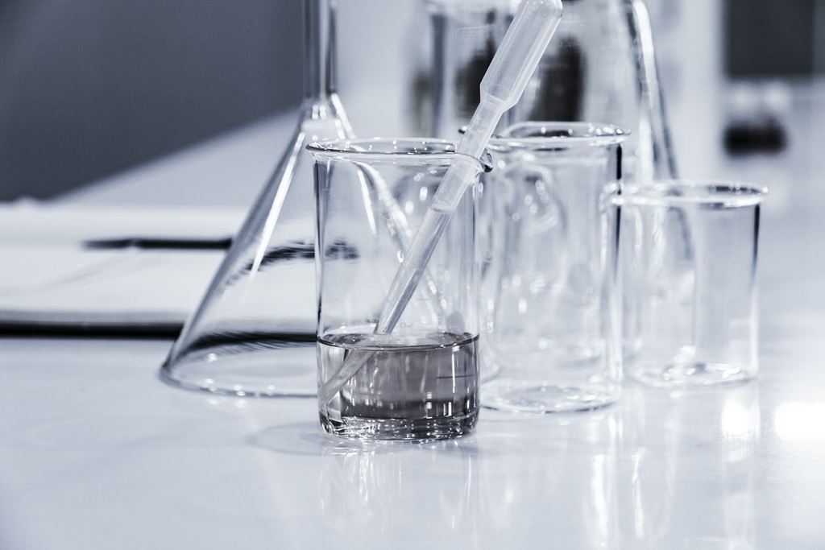

This curriculum has been designed to address the Massachusetts [2016 Science and Technology Engineering Framework](https://www.doe.mass.edu/frameworks/scitech/2016-04.pdf).

[output not shown]

#### Scientific Inquiry and Engineering Design Processes

Additionally, this curriculum addresses and embraces the Scientific Inquiry process and Engineering Design process outlined in that standards framework.

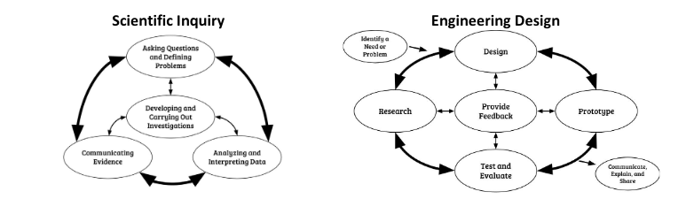

### Design Principles

This course was built with several design principles in mind:

1. **Interdisciplinarity**. We believe that the scientific concepts of this course, as well as the sociological ones, are inherently interdisciplinary in nature. Hence, connections between them are considered important and necessary.
2. **Hands On**. We believe that adolescents learn best when they can engage directly with materials and concepts, and so this course has been designed to include lots of hands on experiences.
3. **Autonomy Support**. We believe that adolescents learn best when they are encouraged and allowed to engage with their learning with as much autonomy as possible, consistent with research into [Self Determination Theory.](https://selfdeterminationtheory.org)
4. **UN Sustainable Development Goals (SDG).** This course has been designed to engage adolescents deeply in the [United Nations Sustainable Development Goals (SDG)](https://www.un.org/en/sustainable-development-goals) and to encourage them as [Earth Citizens](https://www.earthcitizens.org/).
5. **Core Science/Math/Literacy Skills**. This course has been designed to support the development and application of core science, mathematics, and literacy skills.

## Topics/Units of Study

This curriculum includes fivethese topics/units of study.

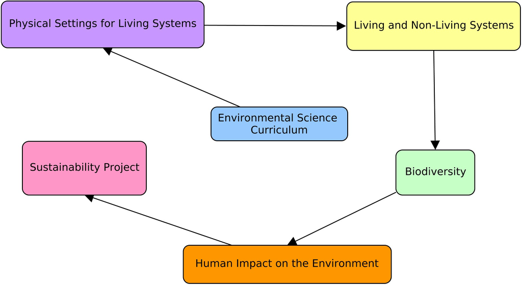

[output not shown]

## Course Units

### Unit 1: Physical Settings for Living Systems

### Unit 2: Living and Non-Living Systems

### [Unit 3: Biodiversity](https://docs.google.com/document/d/1Bgrb4qwGBcupsMQ1rD_0cuCFS_clIWAw1MH5NLA0IgM/edit?usp=sharing)

### Unit 4: Sustainability/Human Impacts on the Environment

### Unit 5: Final Project